# Predicting a song's rank on the *Billboard* Hot 100 chart based on its chord structure

Braden Yang

BIOF509

Fall 2019

## Introduction and Problem Statement

Every week since 1958, *Billboard* magazine compiles their list of the top 100 songs currently trending in the United States. Some songs are instant number one hits, while other songs barely crack the bottom of the chart. Some songs only appear on the chart for as little as one week, while other songs remain near the top for multiple weeks. But is there a secret formula in how a song is written that leads to success in getting to the top of the charts, particularly in the chord structure of a song?

In this BIOF509 Applied Machine Learning project, we will attempt to predict a song's peak rank attained in the *Billboard* Hot 100 chart (the **hotness index**) using information about the chord progressions it uses. We will also attempt to predict how long a song stays on the charts (the **catchiness index**) using the same chord progression features.

## The Dataset

Data was obtained from *The McGill Billboard Project*, which has released annotated text files on 890 total songs . Each text file, which is named "salami_chords.txt", contains full information about the chord structure of a song, along with the key it is in, the time signature, and the verse structure. Link to the data download and citation are listed below:

https://ddmal.music.mcgill.ca/research/The_McGill_Billboard_Project_(Chord_Analysis_Dataset)/

```
John Ashley Burgoyne, Jonathan Wild, and Ichiro Fujinaga, ‘An Expert Ground Truth Set for Audio Chord Recognition and Music Analysis’, in Proceedings of the 12th International Society for Music Information Retrieval Conference, ed. Anssi Klapuri and Colby Leider (Miami, FL, 2011), pp. 633–38, http://ismir2011.ismir.net/papers/OS8-1.pdf.
```

Data in this repository are located in the "data/McGill-Billboard" branch. Each "salami_chords.txt" file is stored in a song-specific directory that is named the integer index that it was assigned in the database.

```python
# An example text file is demonstrated for one such song in the database ("I Feel Good" by James Brown).
f_example = open("data/McGill-Billboard/0314/salami_chords.txt","r")
print(f_example.read())
f_example.close()
```

```
# title: I Got You (I Feel Good)
# artist: James Brown
# metre: 4/4
# tonic: D

0.000000000	silence
0.301859410	A, verse, | D:7 | D:7 | D:7 | D:7 |, (voice
8.979795918	| G:7 | G:7 | D:7 | D:7 |
15.538435374	| A:7 | G:7 | D:7 | D:7 |
22.198276643	A, verse, | D:7 | D:7 | D:7 | D:7 |
28.886938775	| G:7 | G:7 | D:7 | D:7 |
35.522993197	| A:7 | G:7 | D:7 | D:7 |, voice)
42.116553287	B, solo, | N | N | N | N |, (saxophone)
48.710090702	C, bridge, | G:7 | G:7 | D:7 | D:7 |, (voice
55.154557823	| G:7 | G:7 | A:7 | N |
61.718639455	A, verse, | D:7 | D:7 | D:7 | D:7 |
68.359138321	| G:7 | G:7 | D:7 | D:7 |
74.994217687	| A:7 | G:7 | D:7 | D:7 |, voice)
81.548480725	B, solo, | N | N | N | N |, (saxophone)
88.182222222	C, bridge, | G:7 | G:7 | D:7 | D:7 |, (voice
94.662607709	| G:7 | G:7 | A:7 | N |
101.345668934	A, verse, | D:7 | D:7 | D:7 | D:7 |
108.098911564	| G:7 | G:7 | D:7 | D:7 |
114.781723356	| A:7 | G:7 | D:7 | D:7 |
121.458752834	A', verse, | D:7 | D:7 | D:7 | D:7 |
128.150680272	| G:7 | G:7 | D:7 | D:7 |
134.915238095	| A:7 | G:7 | D:7 | D:7 |
141.545192743	| A:7 | G:7 | D:7 | D:7 |
148.261519274	| A:7 | G:7 | D:7 | D:7 | D:7 | D:7 |, voice)
159.134716553	| D:9 |, (trumpet)
165.511836734	silence
168.777142857	end
```

A note on chord notation: chords are sandwiched between the vertical bars "|", and are notated as (pitch):(quality). Pitch can be any of the 12 musical notes (A, B-flat, etc), and quality represents the type of chord (major, minor, 7, etc)

## Import modules

```python
import numpy as np
import pandas as pd
import time
import matplotlib.pyplot as plt
from collections import Counter

# sci-kit learn
from sklearn.model_selection import train_test_split, KFold, cross_validate, GridSearchCV
from sklearn.metrics import r2_score, make_scorer
from sklearn.decomposition import PCA

from sklearn.linear_model import LinearRegression
from sklearn.neighbors import KNeighborsRegressor, KNeighborsClassifier
from sklearn.ensemble import RandomForestRegressor, RandomForestClassifier, AdaBoostClassifier
```

## Define global variables

```python
# dictionary of chord (key) to numeral (value)
CHORD_DICT = {
    'A':0,
    'A#':1,
    'Bb':1,
    'B':2,
    'Cb':2,
    'C':3,
    'C#':4,
    'Db':4,
    'D':5,
    'D#':6,
    'Eb':6,
    'E':7,
    'Fb':7,
    'F':8,
    'F#':9,
    'Gb':8,
    'G':10,
    'G#':11,
    'Ab':11,
}

# dictionary of quality to simplified quality
QUALITY_DICT = {
    'min7':'min',
    'sus4':'sus',
    'maj7':'maj',
    'maj6':'maj',
    'min9':'min',
    'maj9':'maj',
    '9':'7',
    '11':'7',
    'sus2':'sus',
    '13':'7',
    'min6':'min',
    'min11':'min',
    'hdim7':'dim',
    'maj13':'maj',
    'dim7':'dim',
    'minmaj7':'min',
    'min13':'min'
}

# relative path to McGill Billboard data within repository
MCGILL_PATH = "data/McGill-Billboard"

# bool to indicate whether to simplify quality of chords
QUALITY_SIMPLIFY = True

# bool to indicate whether to normalize data based on the total number of sequences of a
# certain length found in a song (reflective of the size of a song)
NORM = False

# list of sequence lengths to search for
SEQ_LEN_LIST = [2,3,4]

# number of chart rank categories to bin into
NUM_CATEGORIES = 5
```

## Define Functions

```python
def parse_data(path):
    """
    Funtion parse_data parses text file provided from the McGill Billboard
    project and returns two lists of lists containing a sequence of chords
    and their qualities respectively
    -----------------------
    Input
        path: string containing absolute path to text file to parse

    Output
        chords: list of lists; each inner list corresponds to a chord sequence
            in an individual line of the song, and contains 2-element tuples
            that give the relative chord numeral and its quality
    """
    # initialize global list
    chords = []
    # iterate over every line
    for line in open(path):
        # set new tonic, if applicable
        if "# tonic:" in line:
            tonic = line.rsplit(" ")[-1][:-1]
        # initialize line-specific lists
        chords_line = []
        # split bars (separated by "|")
        bars = line.rsplit("|")[1:-1]
        # iterate over bars
        for bar in bars:
            # split chords+quality (separated by space)
            cqs = bar.rsplit(" ")[1:-1]
            # iterate over chords+quality
            for cq in cqs:
                # check for existence of ":"
                if ":" in cq:
                    # get chord and convert to relative numeral
                    c = convert_numeral(cq.rsplit(":")[0],tonic)
                    # get quality
                    q = cq.rsplit(":")[-1]
                    if QUALITY_SIMPLIFY:
                        q = q.split("(")[0]
                        q = q.split("/")[0]
                        if q in QUALITY_DICT.keys():
                            q = QUALITY_DICT[q]
                    # append to line list as tuple
                    chords_line.append((c,q))
        # append line list to global list (ignore empty lines)
        if chords_line:
            chords.append(chords_line)

    return chords

def reduce_song(chords):
    """
    Function reduce_song takes in the output of parse_data as input, and outputs a reduced chord
    stored in a single list, with repeated chords removed

    -----------------------
    Input
        chords: list of lists; each inner list corresponds to a chord sequence
            in an individual line of the song, and contains 2-element tuples
            that give the relative chord numeral and its quality (outputed by parse_data

    Output
        chords_reduced: list; reduced form of chords stored in a single list and with repeated chords removed
    """
    # initialize reduced chord sequence list
    chords_reduced = []
    # keep track of previous chord in iteration
    chord_prev = ()
    # iterate over lines
    for line in chords:
        # iterate over chords in line
        for chord in line:
            # check if repeated chord
            if chord == chord_prev:
                pass
            else:
                chords_reduced.append(chord)
                chord_prev = chord

    return chords_reduced

def get_chord_seq(chords_reduced,seq_len):
    """
    Function get_chord_seq parses through a song's chord structure and returns a
    dictionary, with keys representing chord sequences in nested tuples, and values
    representing the counts of each chord sequence found in a particular song.
    User can specify the length of chord sequence to search for

    -----------------------
    Input
        chords_reduced: list containing a song's reduced chord structure (outputed by reduce_song)
        seq_len: int specifying the length of chord sequence to search for

    Output
        seq_dict: dict containing specific chord sequences as keys and the counts of
            each sequence found within the song as values
    """
    # initialize dict
    seq_dict = {}
    # raster over sequences and store in dict
    for i in range(len(chords_reduced) - seq_len + 1):
        seq = tuple(chords_reduced[i:(i+seq_len)]) # get sequence as tuple
        if seq in seq_dict:
            seq_dict[seq] += 1
        else:
            seq_dict[seq] = 1

    return seq_dict

def convert_numeral(chord,tonic):
    """
    Function convert_numeral converts a chord (string) into a
    numeric representation (int) that is relative to the tonic key (string)

    For example, if chord = "F" and tonic = "Bb", then the output would be
    the integer 7
    -----------------------
    Input
        chord: string of the chord to be converted to a numeral
        tonic: string of the tonic key
    Output
        numeral: int representation of "chord"
    """
    numeral = CHORD_DICT[chord] - CHORD_DICT[tonic]
    if numeral < 0:
        return numeral + 12
    else:
        return numeral

def get_decade(d):
    """
    Function get_decade returns a string representing the decade of an input date (also
    string); for example, if '1968-03-01' is inputed, then the output would be '1960'

    -----------------------
    Input
        d: string, input date in the format 'yyyy-mm-dd'

    Output
        decade: string, output decade
    """
    # remove substring past first "-"
    y = float(d.split("-")[0])

    # round to the nearest decade
    decade = str(int(10*np.floor(y/10)))

    return decade

def plot_bar(data,filter_data=False):
    """
    Function plot_bar plots a bar plot of a pair list of items and counts stored in input "data"

    -----------------------
    Input
        data: list of two element lists/tuples that contain name and value pairs to plot in bar plot;
            first element should be the name, second element should be the value
        filter_data: bool indicating whether to filter out values that are less than 1000
    """
    # get counts and labels in separate np arrays
    my_data = np.array([pair[1] for pair in data])
    my_labels = np.array([str(pair[0]) for pair in data])

    # filter out low counts for visualization purposes
    if filter_data:
        idx = my_data > 1000
        my_data = my_data[idx]
        my_labels = my_labels[idx]

    # plot frequency distribution of all chords from all songs
    %matplotlib inline
    plt.figure(figsize=(12,6))
    plt.bar(
        x = range(len(my_data)),
        height = my_data
    );
    plt.xticks(
        ticks=range(len(my_data)),
        labels=my_labels,
        rotation='vertical'
    )
```

## Load in CSV file of metadata

A CSV file containing metadata of all songs is also provided in the *McGill Billboard Project* dataset. This file contains all ranking information such as the peak rank attained and the number of weeks that a song remained on the charts, among other parameters. A large portion of the rows are missing ranking data; these empty rows are filtered out for subsequent analysis.

```python
# load CSV
songs_meta_df = pd.read_csv("data/billboard-2.0-index.csv");

# filter out rows that have NaN in the "actual_rank" column
songs_meta_filter_df = songs_meta_df[songs_meta_df.actual_rank.notnull()].copy().reset_index()

# get song indices
song_id = songs_meta_filter_df.id.values

# get decade and append new column
dates = songs_meta_filter_df.chart_date
decade = [get_decade(date) for date in dates]
decade_ser = pd.Series(decade, name="decade")
songs_meta_filter_df = songs_meta_filter_df.join(decade_ser)

# get chart rank category and append new column
rank_bin = np.digitize(x = songs_meta_filter_df["peak_rank"], bins = np.linspace(1,101,NUM_CATEGORIES+1))
rank_bin_ser = pd.Series(rank_bin, name="peak_rank_category")
songs_meta_filter_df = songs_meta_filter_df.join(rank_bin_ser)

# display head of metadata
songs_meta_filter_df.head()
```

|  | index | id | chart_date | target_rank | actual_rank | title | artist | peak_rank | weeks_on_chart | decade | peak_rank_category |
| --- | --- | --- | --- | --- | --- | --- | --- | --- | --- | --- | --- |
| 0 | 2 | 3 | 1961-07-03 | 56 | 57.0 | I Don't Mind | James Brown | 47.0 | 8.0 | 1960 | 3 |
| 1 | 3 | 4 | 1971-08-07 | 32 | 31.0 | You've Got A Friend | Roberta Flack,Donny Hathaway | 29.0 | 12.0 | 1970 | 2 |
| 2 | 5 | 6 | 1980-08-02 | 15 | 16.0 | The Rose | Bette Midler | 3.0 | 25.0 | 1980 | 1 |
| 3 | 9 | 10 | 1984-03-24 | 49 | 51.0 | An Innocent Man | Billy Joel | 10.0 | 18.0 | 1980 | 1 |
| 4 | 11 | 12 | 1980-11-15 | 65 | 63.0 | Lookin' For Love | Johnny Lee | 5.0 | 21.0 | 1980 | 1 |

For the *hotness index*, we will use the peak rank that a song has ever achieved on the charts (peak_rank), and for the *catchiness index*, we will use the number of weeks that a song has remained on the charts (weeks_on_chart)

## Feature extraction pipeline

Now we will go over the process of parsing through the raw text data and reducing it down to a set of features which contain information about a song's chord sequencing

### Original text file

```python
f_example = open("data/McGill-Billboard/0402/salami_chords.txt","r")
print(f_example.read())
f_example.close()
```

```
# title: Last Kiss
# artist: J. Frank Wilson & The Cavaliers
# metre: 4/4
# tonic: E

0.0	silence
0.139319727	A, intro, | N | N |
3.651292517	| E:maj | C#:min | A:maj | B:maj |
10.588299319	B, chorus, | E:maj | C#:min | A:maj | B:maj |, (voice
17.688117913	| E:maj | C#:min | A:maj | B:maj |, voice)
24.826780045	A', trans, | E:maj | E:maj |
28.337755102	C, verse, | E:maj | C#:min | A:maj | B:maj |, (voice
35.366689342	| E:maj | C#:min | A:maj | B:maj |
42.543854875	| E:maj | C#:min | A:maj | B:maj |
49.625056689	| E:maj | C#:min | A:maj | B:maj |, voice)
56.76786848	A', trans, | E:maj | E:maj |
60.284285714	B, chorus, | E:maj | C#:min | A:maj | B:maj |, (voice
67.257165532	| E:maj | C#:min | A:maj | B:maj |, voice)
74.42446712	A', trans, | E:maj | E:maj |
77.921065759	C, verse, | E:maj | C#:min | A:maj | B:maj |, (voice
85.057800453	| E:maj | C#:min | A:maj | B:maj |
92.196780045	| E:maj | C#:min | A:maj | B:maj |
99.348956916	| E:maj | C#:min | A:maj | B:maj |
106.455192743	| E:maj | C#:min | A:maj | B:maj |, voice)
113.641088435	A', trans, | E:maj | E:maj |
117.119024943	B, chorus, | E:maj | C#:min | A:maj | B:maj |, (voice
124.183945578	| E:maj | C#:min | A:maj | B:maj |, voice)
131.35324263	A', trans, | E:maj | E:maj |
134.731111111	C', outro, | E:maj | C#:min | A:maj | B:maj |
141.831360544	fadeout, | E:maj | C#:min | A:maj | B:maj |
144.567437641	silence
147.69632653	end
```

### Parsed output

```python
chords = parse_data("data/McGill-Billboard/0402/salami_chords.txt") # use function "parse_data"
chords
```

```
[[(0, 'maj'), (9, 'min'), (5, 'maj'), (7, 'maj')],
 [(0, 'maj'), (9, 'min'), (5, 'maj'), (7, 'maj')],
 [(0, 'maj'), (9, 'min'), (5, 'maj'), (7, 'maj')],
 [(0, 'maj'), (0, 'maj')],
 [(0, 'maj'), (9, 'min'), (5, 'maj'), (7, 'maj')],
 [(0, 'maj'), (9, 'min'), (5, 'maj'), (7, 'maj')],
 [(0, 'maj'), (9, 'min'), (5, 'maj'), (7, 'maj')],
 [(0, 'maj'), (9, 'min'), (5, 'maj'), (7, 'maj')],
 [(0, 'maj'), (0, 'maj')],
 [(0, 'maj'), (9, 'min'), (5, 'maj'), (7, 'maj')],
 [(0, 'maj'), (9, 'min'), (5, 'maj'), (7, 'maj')],
 [(0, 'maj'), (0, 'maj')],
 [(0, 'maj'), (9, 'min'), (5, 'maj'), (7, 'maj')],
 [(0, 'maj'), (9, 'min'), (5, 'maj'), (7, 'maj')],
 [(0, 'maj'), (9, 'min'), (5, 'maj'), (7, 'maj')],
 [(0, 'maj'), (9, 'min'), (5, 'maj'), (7, 'maj')],
 [(0, 'maj'), (9, 'min'), (5, 'maj'), (7, 'maj')],
 [(0, 'maj'), (0, 'maj')],
 [(0, 'maj'), (9, 'min'), (5, 'maj'), (7, 'maj')],
 [(0, 'maj'), (9, 'min'), (5, 'maj'), (7, 'maj')],
 [(0, 'maj'), (0, 'maj')],
 [(0, 'maj'), (9, 'min'), (5, 'maj'), (7, 'maj')],
 [(0, 'maj'), (9, 'min'), (5, 'maj'), (7, 'maj')]]
```

This parsed output contains all the chords of a song, line by line, in a reduced format. Each chord is represented as a two-element tuple, with the first element being the relative pitch of the chord and the second element being the quality of the chord. For example, the first chord of the song is stored as (0, 'maj'), indicating that its relative pitch is 0 and its quality is major.

In order to keep the data as standardized as possible, the pitches are converted to integers for simplicity, and are normalized relative to the key of a song.

*Music theory sidenote*: a G major chord in the key of C is the same as a C major chord in the key of F; both G major and C major are serving as the 5-chords in their respective keys. They function as the same type of chord *relative* to the key, and therefore we must store them in a way that is reflective of this. This is why we normalize chord pitches based on the key.

Numbering of pitches starts at 0 on the tonic pitch (i.e. the key of the song) and increases incrementally by one at each step up the keyboard.

In this case, G major in the key of C and C major in the key of F would both be assigned the number -> 7

#### In the key of C major

[figure not shown]

#### In the key of F major

[figure not shown]

For the qualities of chords, there were hundreds of unique qualities annotated in the raw text data. In reality, these different qualities are variations of 8 fundamental qualities, so I decided to reduce the qualities into their fundamental forms:

- major (maj)
- minor (min)
- 7th (7)
- suspended (sus)
- diminished (dim)
- augmented (aug)
- power (5)
- unharmonized bass note (1)

Moving forward with feature extraction, the chord data structure of a song is further reduced to a single string of chords which represents the pure sequence of chords in the song. *All repeated chords are removed so that no two chords adjacent to each other are the same*

```python
chords
```

```
[[(0, 'maj'), (9, 'min'), (5, 'maj'), (7, 'maj')],
 [(0, 'maj'), (9, 'min'), (5, 'maj'), (7, 'maj')],
 [(0, 'maj'), (9, 'min'), (5, 'maj'), (7, 'maj')],
 [(0, 'maj'), (0, 'maj')],
 [(0, 'maj'), (9, 'min'), (5, 'maj'), (7, 'maj')],
 [(0, 'maj'), (9, 'min'), (5, 'maj'), (7, 'maj')],
 [(0, 'maj'), (9, 'min'), (5, 'maj'), (7, 'maj')],
 [(0, 'maj'), (9, 'min'), (5, 'maj'), (7, 'maj')],
 [(0, 'maj'), (0, 'maj')],
 [(0, 'maj'), (9, 'min'), (5, 'maj'), (7, 'maj')],
 [(0, 'maj'), (9, 'min'), (5, 'maj'), (7, 'maj')],
 [(0, 'maj'), (0, 'maj')],
 [(0, 'maj'), (9, 'min'), (5, 'maj'), (7, 'maj')],
 [(0, 'maj'), (9, 'min'), (5, 'maj'), (7, 'maj')],
 [(0, 'maj'), (9, 'min'), (5, 'maj'), (7, 'maj')],
 [(0, 'maj'), (9, 'min'), (5, 'maj'), (7, 'maj')],
 [(0, 'maj'), (9, 'min'), (5, 'maj'), (7, 'maj')],
 [(0, 'maj'), (0, 'maj')],
 [(0, 'maj'), (9, 'min'), (5, 'maj'), (7, 'maj')],
 [(0, 'maj'), (9, 'min'), (5, 'maj'), (7, 'maj')],
 [(0, 'maj'), (0, 'maj')],
 [(0, 'maj'), (9, 'min'), (5, 'maj'), (7, 'maj')],
 [(0, 'maj'), (9, 'min'), (5, 'maj'), (7, 'maj')]]
```

```python
chords_reduced = reduce_song(chords)  # use function "reduce_song"
print(chords_reduced)
```

[output not shown]

Lastly, subsequences of a specified length are extracted within an overall chord sequence of a song, and the total counts of each unique subsequence are tallied in a dictionary

```python
my_dict = get_chord_seq(chords_reduced,2)  # use function "get_chord_seq"
my_dict
```

```
{((0, 'maj'), (9, 'min')): 18,
 ((9, 'min'), (5, 'maj')): 18,
 ((5, 'maj'), (7, 'maj')): 18,
 ((7, 'maj'), (0, 'maj')): 17}
```

Each unique subsequence will be used as its own feature for a song's chord sequence characteristics, and hence will be used to build predictive models on a song's performance in the *Billboard* Hot 100 charts.

## Parse all text files and extract chord sequence data

This step parses through **all** chord text files and extracts the overall chord structure along with chord sequence features. Currently, this code is set up to extract sequences of length 2, 3 and 4 (see SEQ_LEN_LIST in global variables cell)

```python
# initialize dicts to keep track of global counts
num_cq = {}
num_chord = {}
num_quality = {}

# initialize list of dicts to keep track of song chord sequences
song_seq_all = []

# iterate through all songs
for song in song_id:
    # parse song
    chords = parse_data(MCGILL_PATH + f"/{str(song).zfill(4)}/salami_chords.txt")
    # reduce song chord sequence
    chords_reduced = reduce_song(chords)

    # -------- EXTRACT SONG-SPECIFIC CHORD SEQUENCES --------
    # initialize song chord sequence dict
    song_seq = {}

    # iterate over different sequence lengths, add to song_seq
    for seq_len in SEQ_LEN_LIST:
        # get dict of chord sequence counts for sequences of length seq_len
        dict_temp = get_chord_seq(chords_reduced,seq_len)
        # add to total count of sequences of all lengths
        song_seq.update(dict_temp)

    # append song_seq to song_seq_all
    song_seq_all.append(song_seq)

    # ----------------- FIND GLOBAL COUNTS ------------------
    # iterate through lines in a song
    for line in chords:
        # iterate through individual chords
        for chord in line:
            # populate dicts
            if chord in num_cq:
                num_cq[chord] += 1
            else:
                num_cq[chord] = 1

            if chord[0] in num_chord:
                num_chord[chord[0]] += 1
            else:
                num_chord[chord[0]] = 1

            if chord[1] in num_quality:
                num_quality[chord[1]] += 1
            else:
                num_quality[chord[1]] = 1

# sort key-value pairs by values
cq_sort = sorted(num_cq.items(), key = lambda kv: kv[1], reverse=True)
quality_sort = sorted(num_quality.items(), key = lambda kv: kv[1], reverse=True)
chord_sort = sorted(num_chord.items(), key = lambda kv: kv[1], reverse=True)

# get counts of all unique chord sequences
seq_total_count = Counter({})
for song in song_seq_all:
    seq_total_count = seq_total_count + Counter(song)
```

### Plot overall distributions

#### CHORD AND QUALITY

```
[((0, 'maj'), 27265), ((5, 'maj'), 15807), ((7, 'maj'), 10087), ((0, 'min'), 8343), ((9, 'min'), 5204), ((10, 'maj'), 4580), ((2, 'min'), 4575), ((7, '7'), 4327), ((0, '7'), 3814), ((8, 'maj'), 2855)]
```

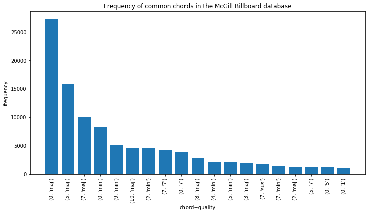

```python
# plot chord and quality
plot_bar(cq_sort,filter_data=True)
plt.title("Frequency of common chords in the McGill Billboard database")
plt.xlabel("chord+quality")
plt.ylabel("frequency")
# print out top 10 chord+quality by count
print(cq_sort[0:10])
```

#### CHORD ONLY

```
[(0, 42440), (5, 20280), (7, 18341), (2, 7006), (9, 6810), (10, 5778), (4, 3641), (8, 3362), (3, 2603), (1, 765), (6, 653), (11, 628)]
```

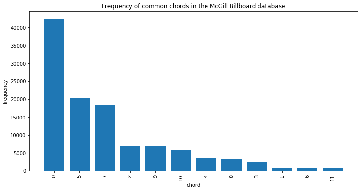

```python
plot_bar(chord_sort)
plt.title("Frequency of common chords in the McGill Billboard database")
plt.xlabel("chord")
plt.ylabel("frequency")
print(chord_sort)
```

#### QUALITY ONLY

```
[('maj', 66578), ('min', 24564), ('7', 11782), ('sus', 3736), ('5', 2580), ('1', 2362), ('dim', 510), ('aug', 195)]
```

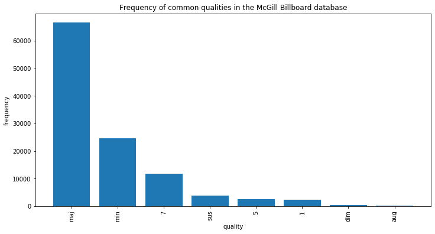

```python
plot_bar(quality_sort)
plt.title("Frequency of common qualities in the McGill Billboard database")
plt.xlabel("quality")
plt.ylabel("frequency")
print(quality_sort)
```

## Add chord sequence features to pandas dataframe

This step will populate a pandas dataframe with our chord sequence features. Each row represents a song (songs will be in the same order as in the filtered metadata dataframe, songs_meta_filter_df), and each column represents a unique chord sequence.

```python
start = time.time() # start time

# instantiate feature dataframe for all songs
df_features = pd.DataFrame()
# iterate over all song chord progressions
for idx, song_seq in enumerate(song_seq_all):
    # if dict not empty
    if song_seq:
        # initialize row
        df_row = pd.DataFrame()
        # iterate over all key/value pairs
        for kv in song_seq.items():
            # populate dataframe
            df_row.loc[0,str(kv[0])] = kv[1]
        # concatentate df_features
        df_features = df_features.append(
            other=df_row,
            ignore_index=True,
            sort=True
        )
    else:
        df_features = df_features.append(pd.Series(),ignore_index=True)
    # print statement
    if not np.mod(idx,100):
        print("line " + str(idx) + " done")

end = time.time() # end time
print("Time elapsed: " + str(end - start)) # time elapsed

# fill NaN values with 0
df_features = df_features.fillna(value=0)
```

```
line 0 done
line 100 done
line 200 done
line 300 done
line 400 done
line 500 done
line 600 done
line 700 done
line 800 done
Time elapsed: 121.66866278648376
```

#### Show head and shape of dataframe

```python
df_features.head()
```

|  | ((0, '1'), (0, '5')) | ((0, '1'), (0, '5'), (0, '1')) | ((0, '1'), (0, '5'), (0, '1'), (0, '5')) | ((0, '1'), (0, '5'), (0, '1'), (5, '1')) | ((0, '1'), (0, '5'), (0, '1'), (5, 'maj')) | ((0, '1'), (0, '5'), (0, 'min')) | ((0, '1'), (0, '5'), (0, 'min'), (7, 'min')) | ((0, '1'), (0, '5'), (0, 'min'), (8, 'maj')) | ((0, '1'), (0, '5'), (3, 'maj')) | ((0, '1'), (0, '5'), (3, 'maj'), (10, 'maj')) | ... | ((9, 'sus'), (9, 'min'), (4, 'min')) | ((9, 'sus'), (9, 'min'), (4, 'min'), (7, 'sus')) | ((9, 'sus'), (9, 'min'), (4, 'sus')) | ((9, 'sus'), (9, 'min'), (4, 'sus'), (9, 'sus')) | ((9, 'sus'), (9, 'min'), (5, 'sus')) | ((9, 'sus'), (9, 'min'), (5, 'sus'), (5, 'maj')) | ((9, 'sus'), (9, 'min'), (7, 'maj')) | ((9, 'sus'), (9, 'min'), (7, 'maj'), (5, '5')) | ((9, 'sus'), (9, 'min'), (9, 'sus')) | ((9, 'sus'), (9, 'min'), (9, 'sus'), (9, 'min')) |
| --- | --- | --- | --- | --- | --- | --- | --- | --- | --- | --- | --- | --- | --- | --- | --- | --- | --- | --- | --- | --- | --- |
| 0 | 0.0 | 0.0 | 0.0 | 0.0 | 0.0 | 0.0 | 0.0 | 0.0 | 0.0 | 0.0 | ... | 0.0 | 0.0 | 0.0 | 0.0 | 0.0 | 0.0 | 0.0 | 0.0 | 0.0 | 0.0 |
| 1 | 0.0 | 0.0 | 0.0 | 0.0 | 0.0 | 0.0 | 0.0 | 0.0 | 0.0 | 0.0 | ... | 0.0 | 0.0 | 0.0 | 0.0 | 0.0 | 0.0 | 0.0 | 0.0 | 0.0 | 0.0 |
| 2 | 0.0 | 0.0 | 0.0 | 0.0 | 0.0 | 0.0 | 0.0 | 0.0 | 0.0 | 0.0 | ... | 0.0 | 0.0 | 0.0 | 0.0 | 0.0 | 0.0 | 0.0 | 0.0 | 0.0 | 0.0 |
| 3 | 0.0 | 0.0 | 0.0 | 0.0 | 0.0 | 0.0 | 0.0 | 0.0 | 0.0 | 0.0 | ... | 0.0 | 0.0 | 0.0 | 0.0 | 0.0 | 0.0 | 0.0 | 0.0 | 0.0 | 0.0 |
| 4 | 0.0 | 0.0 | 0.0 | 0.0 | 0.0 | 0.0 | 0.0 | 0.0 | 0.0 | 0.0 | ... | 0.0 | 0.0 | 0.0 | 0.0 | 0.0 | 0.0 | 0.0 | 0.0 | 0.0 | 0.0 |

5 rows × 17385 columns

```python
df_features.shape
```

```
(890, 17385)
```

There are quite a number of zero entries in our feature dataframe. This is most likely due to the fact that songs do not share many chord sequences with one another. The existence of a column means that that chord sequence has been found in at least one song, but the zeros in the column also indicate that that chord sequence hasn't been found in many of the other songs.

Also note that the total number of features, or columns, in this dataframe (17385) is quite large as well. This may also contribute to the sparcity of our dataframe (the *curse of dimensionality*).

Before building our predictive models, we must first reduce the number of features. *Principal component analysis* will be employed to shrink the number of features down to 100.

## Principal Component Analysis (PCA) for feature reduction

```python
# apply PCA to features
my_pca = PCA(n_components = 100)

# apply PCA on chord progression features
pc = my_pca.fit_transform(df_features)

# store principal components as dataframe
col_names = ["pc" + str(idx) for idx in range(1,pc.shape[1]+1)] # get PC names
pc_df = pd.DataFrame(data=pc, columns=col_names)                # make dataframe
pc_df.head()
```

|  | pc1 | pc2 | pc3 | pc4 | pc5 | pc6 | pc7 | pc8 | pc9 | pc10 | ... | pc91 | pc92 | pc93 | pc94 | pc95 | pc96 | pc97 | pc98 | pc99 | pc100 |
| --- | --- | --- | --- | --- | --- | --- | --- | --- | --- | --- | --- | --- | --- | --- | --- | --- | --- | --- | --- | --- | --- |
| 0 | -9.093352 | -1.350986 | -2.623217 | 0.722676 | -3.839283 | -3.840705 | 6.223658 | -1.921367 | -2.355084 | 2.221743 | ... | 0.793210 | 0.781166 | -0.190464 | 0.004878 | 1.128273 | 0.808523 | 0.571088 | -0.205333 | 1.328030 | -0.284810 |
| 1 | 4.246911 | -8.630045 | -4.961611 | 1.306483 | -2.620419 | -1.018290 | -1.612576 | 0.824388 | -1.045955 | -1.259222 | ... | 0.920649 | -0.849336 | -0.745984 | 0.903041 | 1.353398 | -0.021099 | -0.325587 | 1.411046 | 0.938054 | -0.663514 |
| 2 | -2.980933 | 17.920002 | 3.301078 | -8.379466 | 1.637307 | -0.826611 | -1.302266 | 8.298866 | -3.397126 | -0.561736 | ... | -1.635960 | -0.217311 | -0.772721 | -0.297784 | -0.797942 | 1.770482 | -0.185037 | 0.340724 | -0.062298 | 1.059687 |
| 3 | 20.526971 | 21.738587 | 2.432119 | 18.884578 | -2.996945 | 12.469323 | -0.160966 | -2.962354 | 0.031091 | 1.972762 | ... | 2.551950 | 4.177840 | 5.554185 | 1.766423 | 6.086295 | -3.784647 | 3.847956 | 1.393078 | 6.289800 | -1.369969 |
| 4 | 5.501799 | 4.271461 | -0.910192 | -2.506990 | -0.622664 | -1.248531 | -0.746111 | -2.239382 | 0.458384 | -0.163711 | ... | 1.690514 | -0.849934 | 1.511310 | -1.518725 | -3.572924 | -0.401733 | 2.006850 | -0.117452 | -0.017048 | 0.915178 |

5 rows × 100 columns

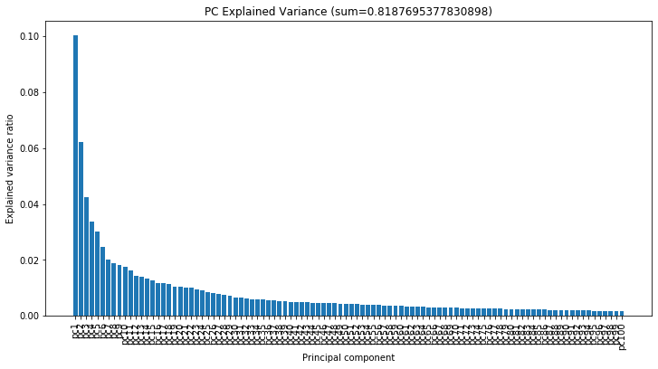

```python
# plot explained variance
evr_list = my_pca.explained_variance_ratio_
my_data = [(name,evr) for name,evr in zip(col_names,evr_list)]
plot_bar(my_data)
plt.title(f"PC Explained Variance (sum={str(np.sum(evr_list))})");
plt.xlabel("Principal component");
plt.ylabel("Explained variance ratio");
```

## Build regressors to predict hotness and catchiness

Now we will build several predictive models to try and predict the hotness and catchiness indices using our principal components. Models that will be tested out include:

- Multivariate linear regression
- K-nearest neighbors (grid-search over # of neighbors)
- Random forest regressor (# estimators = 20, grid-search over max depth)

Cross validation will be performed at each grid search iteration, with 10 splits being used, to evaluate the accuracy of the model in predicting either hotness or catchiness.

#### Set up data for predictive modeling

```python
# FEATURES X
X_all = pc_df  # PC data

# CONTINUOUS y
hotness = songs_meta_filter_df["peak_rank"]  # peak rank (continuous)
catchiness = songs_meta_filter_df["weeks_on_chart"]  # weeks on chart (continuous)

# CATEGORICAL y
hotness_category = songs_meta_filter_df["peak_rank_category"]  # peak rank category
decade = songs_meta_filter_df["decade"]  # decade
```

#### HOTNESS INDEX

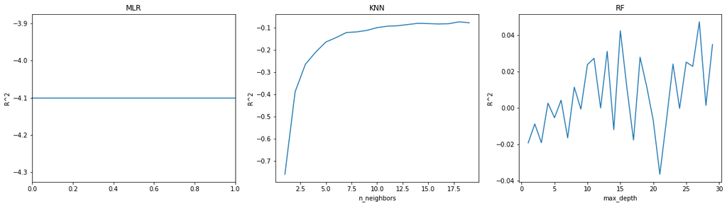

```python
sp = plt.subplots(1,3,figsize=(20,5));

# ---------- MULTIVARIATE LINEAR REGRESSION ----------
# instantiate a KFold instance
kf = KFold(n_splits=10, shuffle=True,random_state=10)
# instantiate a linear regression instance
lr = LinearRegression()
# perform cross-validation using linear regression on original chord sequence data
cv_lr = cross_validate(
    estimator=lr,
    X=X_all, y=hotness,
    cv=kf,
    scoring=make_scorer(r2_score)
)
cv_lr_df = pd.DataFrame(cv_lr)
mean_test_score = np.mean(cv_lr_df["test_score"])
plt.subplot(1,3,1, title="MLR", ylabel="R^2");
plt.axhline(mean_test_score);

# ---------- KNN ----------
# Create kf instance
kf = KFold(n_splits=10, shuffle=True, random_state=42)
# Create knn instance
knn = KNeighborsRegressor()
# Create grid search instance
gscv = GridSearchCV(knn, {"n_neighbors": range(1, 20)}, cv=kf, n_jobs=-1)
gscv.fit(X_all, hotness)
# Get cross-validation data
cv_df = pd.DataFrame(gscv.cv_results_)
# Plot results of grid search
plt.subplot(1,3,2, title="KNN", xlabel="n_neighbors", ylabel="R^2");
plt.plot(cv_df["param_n_neighbors"], cv_df["mean_test_score"]);

# ---------- RANDOM FOREST ----------
# Create kf instance
kf = KFold(n_splits=10, shuffle=True, random_state=42)
# Create rf instance
rf = RandomForestRegressor(n_estimators=20)
# Create grid search instance
gscv = GridSearchCV(rf,{"max_depth": range(1,30)},cv=kf, n_jobs=-1)
# Run grid search
gscv.fit(X_all, hotness)
# Get cross-validation data
cv_df = pd.DataFrame(gscv.cv_results_)
# Plot results of grid search
plt.subplot(1,3,3, title="RF", xlabel="max_depth", ylabel="R^2");
plt.plot(cv_df["param_max_depth"], cv_df["mean_test_score"]);
```

#### CATCHINESS INDEX

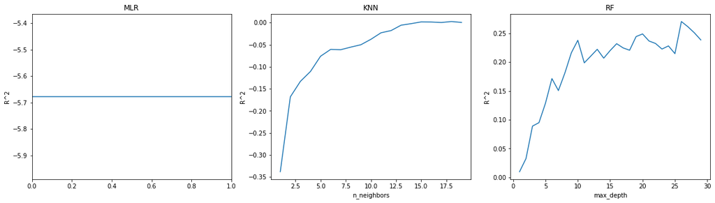

```python
sp = plt.subplots(1,3,figsize=(20,5));

# ---------- MULTIVARIATE LINEAR REGRESSION ----------
# instantiate a KFold instance
kf = KFold(n_splits=10, shuffle=True,random_state=10)
# instantiate a linear regression instance
lr = LinearRegression()
# perform cross-validation using linear regression on original chord sequence data
cv_lr = cross_validate(
    estimator=lr,
    X=X_all, y=catchiness,
    cv=kf,
    scoring=make_scorer(r2_score)
)
cv_lr_df = pd.DataFrame(cv_lr)
mean_test_score = np.mean(cv_lr_df["test_score"])
plt.subplot(1,3,1, title="MLR", ylabel="R^2");
plt.axhline(mean_test_score);

# ---------- KNN ----------
# Create kf instance
kf = KFold(n_splits=10, shuffle=True, random_state=42)
# Create knn instance
knn = KNeighborsRegressor()
# Create grid search instance
gscv = GridSearchCV(knn, {"n_neighbors": range(1, 20)}, cv=kf, n_jobs=-1)
gscv.fit(X_all, catchiness)
# Get cross-validation data
cv_df = pd.DataFrame(gscv.cv_results_)
# Plot results of grid search
plt.subplot(1,3,2, title="KNN", xlabel="n_neighbors", ylabel="R^2");
plt.plot(cv_df["param_n_neighbors"], cv_df["mean_test_score"]);

# ---------- RANDOM FOREST ----------
# Create kf instance
kf = KFold(n_splits=10, shuffle=True, random_state=42)
# Create rf instance
rf = RandomForestRegressor(n_estimators=20)
# Create grid search instance
gscv = GridSearchCV(rf,{"max_depth": range(1,30)},cv=kf, n_jobs=-1)
# Run grid search
gscv.fit(X_all, catchiness)
# Get cross-validation data
cv_df = pd.DataFrame(gscv.cv_results_)
# Plot results of grid search
plt.subplot(1,3,3, title="RF", xlabel="max_depth", ylabel="R^2");
plt.plot(cv_df["param_max_depth"], cv_df["mean_test_score"]);
```

Yikes! The negative test scores indicate that the model performs worse than the baseline (predicting with the mean), which is not what we want.

It seems that the multiple linear regression and K-nearest neighbors models do not perform well with predicting either hotness index or catchiness index, as evidence by R^2 in the negatives.

It seems that the Random Forest regressor performs the best out of the three regression models, although by not that much. For hotness, even though many of the mean test scores are now in the positive, they still hover close to 0. For catchiness, however, as the max depth increases to about 10, the mean test score hovers around 0.2, a significant improvement compared to previous models.

## Build classifiers to predict hotness category and decade of song

One more question that I wanted to address was this: would we fare better if we predicted a category of hotness instead of the continuous value, i.e. treating hotness as a categorical variable and building a classifier to predict it?

To do this, we discretize each peak rank into one of 5 bins (or however many specified in the global variables cell). Ranks 1-20 would be assigned to bin 1, ranks 21-40 to bin 2, so on and so forth. Classifiers are then trained using the categorical hotness data and evaluated using the same cross-validation split as before (10 splits, random state = 42).

Just for fun, we'll also attempt to predict the decade in which a song was released using the chord sequence PC features.

The following classifiers are tested and grid-searched for optimal parameters:

- K-nearest neighbors
- Random forest
- AdaBoost classifier

#### HOTNESS CATEGORY

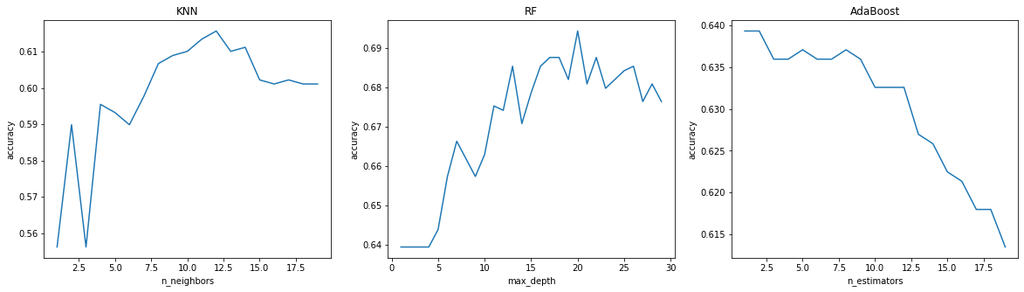

```python
sp = plt.subplots(1,3,figsize=(20,5));

# -------------------- KNN --------------------
# Create kf instance
kf = KFold(n_splits=10, shuffle=True, random_state=42)
# Create knn instance
knn = KNeighborsClassifier()
# Create grid search instance
gscv = GridSearchCV(knn, {"n_neighbors": range(1, 20)}, cv=kf, n_jobs=-1)
gscv.fit(X_all, hotness_category)
# Get cross-validation data
cv_df = pd.DataFrame(gscv.cv_results_)
# Plot results of grid search
plt.subplot(1,3,1, title="KNN", xlabel="n_neighbors", ylabel="accuracy");
plt.plot(cv_df["param_n_neighbors"], cv_df["mean_test_score"]);

# -------------------- RF --------------------
# Create kf instance
kf = KFold(n_splits=10, shuffle=True, random_state=42)
# Create rf instance
rf = RandomForestClassifier(n_estimators=20)
# Create grid search instance
gscv = GridSearchCV(rf, {"max_depth": range(1,30)}, cv=kf, n_jobs=-1)
gscv.fit(X_all, hotness_category)
# Get cross-validation data
cv_df = pd.DataFrame(gscv.cv_results_)
# Plot results of grid search
plt.subplot(1,3,2, title="RF", xlabel="max_depth", ylabel="accuracy");
plt.plot(cv_df["param_max_depth"], cv_df["mean_test_score"]);

# -------------------- ADABOOST --------------------
# Create kf instance
kf = KFold(n_splits=10, shuffle=True, random_state=42)
# Create rf instance
ada = AdaBoostClassifier(n_estimators=20)
# Create grid search instance
gscv = GridSearchCV(ada, {"n_estimators": range(1,20)}, cv=kf, n_jobs=-1)
gscv.fit(X_all, hotness_category)
# Get cross-validation data
cv_df = pd.DataFrame(gscv.cv_results_)
# Plot results of grid search
plt.subplot(1,3,3, title="AdaBoost", xlabel="n_estimators", ylabel="accuracy");
plt.plot(cv_df["param_n_estimators"], cv_df["mean_test_score"]);
```